# Taller 4: Datos vectoriales con {sf}

Uso Avanzado de Sistemas de Información Geográfica

Autor/a

Afiliación

Dr. Francisco Zambrano

Escuela de Ingeniería en Medio Ambiente, Universidad Mayor

Fecha de publicación

16 de septiembre de 2024

# 1 Descripción

En la primera parte del curso se familiarizó con R (R Core Team 2023), las principales estructuras de datos, como realizar indexación, conoció algunas funciones y pudo realizar algunos gráficos básicos; utilizando R base. Ahora, en el curso hemos empezado a trabajar en R con datos geoespaciales de tipo vectoriales y raster. Para manejar datos vectoriales utilizamos {sf} (Pebesma 2018) y para datos de tipo raster {terra}(Hijmans 2023). En este taller trabajaremos con {sf}.

# 2 Objetivo del taller

Familiarizarce con {sf} para crear datos vectoriales, asignarles SRC, transformar los SRC, leer y guardar archivos vectoriales desde/hacia el disco, y explorar la estructura de las capas.

# 3 Instalar y cargar {sf}

Hasta el momento en el curso hemos trabajado con los paquetes que vienen inculidos en R base (stats, graphics, grDevices, utils, datasets, methods y base). Ahora empezaremos a trabajar con paquetes adicionales que no vienen instalados por defecto en R, por lo que deberá instalarlos y cargarlos en R. En este taller trabajaremos con {sf} para poder manejar datos espaciales vectoriales.

Para instala y cargar {sf} debe realizar lo siguiente:

**Código**

```r
# instala {sf}
install.packages('sf')

# cargar {sf} en el entorno de R para poder utilizar
# las funciones adicionales para manejo de datos vectoriales que contiene

library(sf)
```

# 4 Data

Se proporcionan capas vectoriales con los que deberá trabajar en el taller, estas corresponden a estaciones de calidad de aire y capas de biodiversidad, ubicados en Chile.

El archivo comprimido (.zip) que contiene los archivos los debe descargar desde [acá](https://drive.google.com/file/d/13YYw8KDhEab3sLeMwOCcQ7Wk1WAUCojc/view?usp=sharing).

¿Qué debe entregar?

Debe guardar el script con el nombre taller4.R. Los archivos los debe subir en el campus virtual en la sección Actividades -> Evaluaciones -> Talleres -> Taller4

# 5 Fecha de entrega

Lunes 23 de septiembre hasta las 08:30am

# 6 Referencias

Hijmans, Robert J. 2023. terra: Spatial Data Analysis. https://CRAN.R-project.org/package=terra.

Pebesma, Edzer. 2018. «Simple Features for R: Standardized Support for Spatial Vector Data». The R Journal 10 (1): 439-46. https://doi.org/10.32614/RJ-2018-009.

R Core Team. 2023. R: A Language and Environment for Statistical Computing. Vienna, Austria: R Foundation for Statistical Computing. https://www.R-project.org/.

# 7 Ejercicios

1- (10pts) Cree un objeto sfg de tipo punto de dos, tres y cuatro dimensiones. Utilicé las coordenadas de latitud -36.25 y longitud -72.65 una elevación de 200 metros y una direccción de 90°. Revise la estructura del objeto creado utilizando la función str.

**Código**

```r
library(sf)
```

**Código**

```r
punto <- st_point(c(-72.65,-36.25,200,90))
str(punto)
```

```
 'XYZM' num [1:4] -72.7 -36.2 200 90
```

2- (20pts) Utilice las siguientes coordenadas para crear los siguientes tipos de objetos sfg:

```
MULTIPOINT
LINESTRING
```

Verifique que la clase y geometría del objeto es la correspondiente y haga un plot de cada objeto.

**Código**

```r
df <- data.frame(
  latitud = c(-33.38991,-33.38959,-33.38929,-33.38893),
  longitud = c(-70.63500,-70.63468,-70.63435,-70.63396)
)
```

**Código**

```r
library(sf)
mp <-  st_multipoint(as.matrix(df[,2:1]))
class(mp)
```

```
[1] "XY"         "MULTIPOINT" "sfg"
```

**Código**

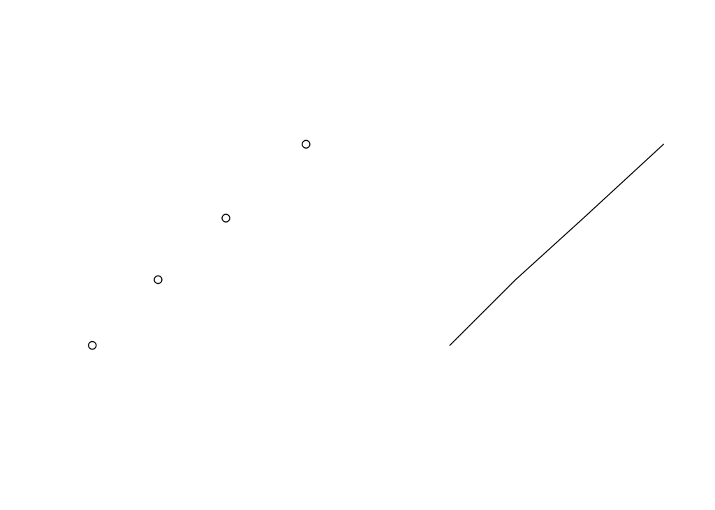

```r
ls <- st_linestring(as.matrix(df[,2:1]))
par(mfrow = c(1,2))
plot(mp)
plot(ls)
```

3- (20pts) Utilice las siguientes coordenadas para crear un objeto sfg de tipo MULTILINESTRING que contenga dos lineas. Verifique que la clase y geometría del objeto es la correspondiente y haga un plot de cada objeto.

**Código**

```r
df <- data.frame(
  linea = c(rep('linea_1',4),rep('linea_2',4)),
  latitud = c(-33.38991,-33.38959,-33.38929,-33.38893,
              -33.38943,-33.38911,-33.38883,-33.38846),
  longitud = c(-70.63500,-70.63468,-70.63435,-70.63396,
               -70.63566,-70.63531,-70.63500,-70.63461)
)
```

**Código**

```r
mdf <- as.matrix(df[,3:2])
mls <- st_multilinestring(list(mdf[1:4,],mdf[5:8,]))
class(mls)
```

```
[1] "XY"              "MULTILINESTRING" "sfg"
```

**Código**

```r
st_geometry_type(mls)
```

```
[1] MULTILINESTRING
18 Levels: GEOMETRY POINT LINESTRING POLYGON MULTIPOINT ... TRIANGLE
```

**Código**

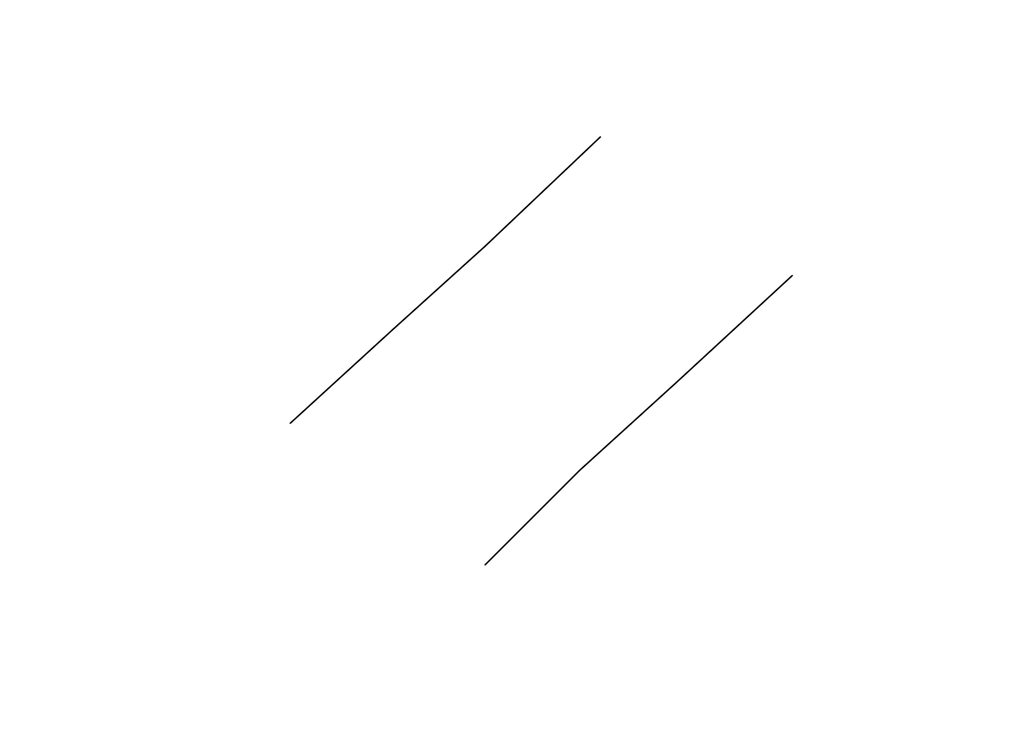

```r
plot(mls)
```

4- (20pts) Utilice las coordenadas en el data.frame df_pol para crear un objeto sfg de tipo POLYGON. Verifique que la clase y geometría del objeto es la correspondiente y haga un plot de cada objeto

**Código**

```r
df_pol <- data.frame(
  latitud = c(-33.38943,-33.38911,-33.38959,-33.38991),
  longitud = c(-70.63566,-70.63531,-70.63468,-70.63500)
)
```

**Código**

```r
mdf_pol <- as.matrix(df_pol)
pol <- st_polygon(list(mdf_pol[c(1:4,1),]))
class(pol)
```

```
[1] "XY"      "POLYGON" "sfg"
```

**Código**

```r
st_geometry_type(pol)
```

```
[1] POLYGON
18 Levels: GEOMETRY POINT LINESTRING POLYGON MULTIPOINT ... TRIANGLE
```

**Código**

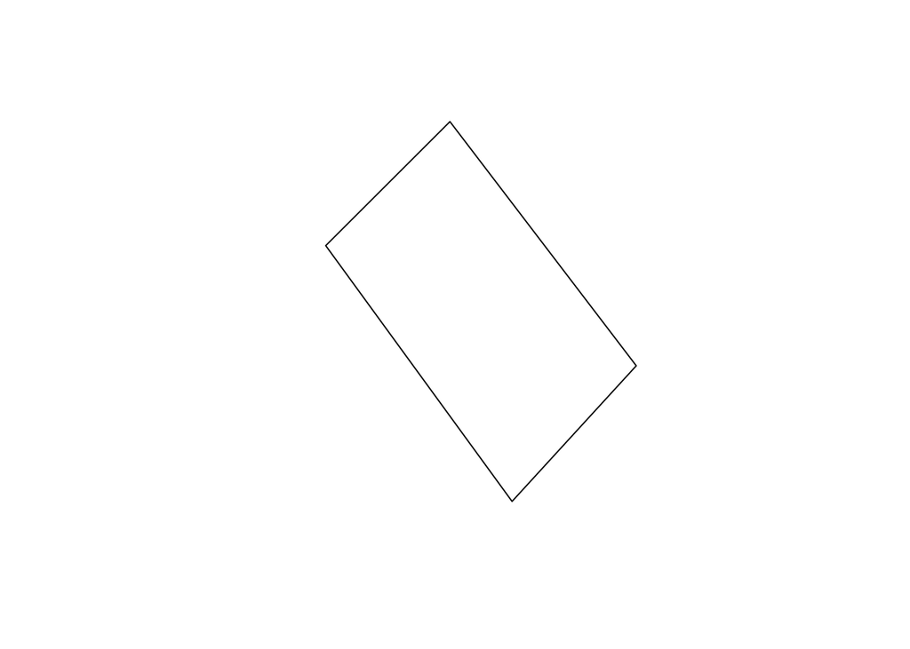

```r
plot(pol)
```

5- (20pts) Utilice las coordenadas en el data.frame df_mpol para crear un objeto sfg de tipo MULTIPOLYGON que contenga dos polygonos. Verifique que la clase y geometría del objeto es la correspondiente y haga un plot de cada objeto.

**Código**

```r
df_mpol <- data.frame(
  poligono = c(rep('poligono_1',4),rep('poligono_2',4)),
   latitud = c(-33.38943,-33.38911,-33.38959,-33.38991,
               -33.38883,-33.38846,-33.38893,-33.38929),
  longitud = c(-70.63566,-70.63531,-70.63468,-70.63500,
               -70.63500,-70.63461,-70.63396,-70.63435)
)
```

**Código**

```r
mdf_mpol <- as.matrix(df_mpol[,3:2])

mpol<- st_multipolygon(list(
  list(mdf_mpol[c(1:4,1),]),
  list(mdf_mpol[c(5:8,5),])
  ))
class(mpol)
```

```
[1] "XY"           "MULTIPOLYGON" "sfg"
```

**Código**

```r
st_geometry_type(mpol)
```

```
[1] MULTIPOLYGON
18 Levels: GEOMETRY POINT LINESTRING POLYGON MULTIPOINT ... TRIANGLE
```

6- (20pts) Junte todas las geometrias anteriores en un objteo sfg de tipo GEOMETRY COLLECTION. Verifique que la clase y geometría del objeto es la correspondiente y haga un plot de cada objeto

**Código**

```r
gc <- st_geometrycollection(list(st_zm(punto,'ZM'),mp,ls,mls,pol,mpol))
class(gc)
```

```
[1] "XY"                 "GEOMETRYCOLLECTION" "sfg"
```

**Código**

```r
st_geometry_type(gc)
```

```
[1] GEOMETRYCOLLECTION
18 Levels: GEOMETRY POINT LINESTRING POLYGON MULTIPOINT ... TRIANGLE
```

**Código**

```r
plot(gc)
```

[output not shown]

7- (20pts) Utilice las función st_sfc para convertir los objetos sfg en tipo sfc (salvo para la geometry collection), luego utilice la función st_sf para crear un objeto sf que contenga todas las geometrias. Agregue una columna nombre_geometria a los atributos en donde se identifique el tipo de geometria (ej, multipoligono, multilinea, multipuntos,etc).

**Código**

```r
geometrs <- st_sfc(st_zm(punto,'ZM'),mp,ls,mls,pol,mpol)
geoms_sf <- st_sf(geometrs)
geoms_sf$tipo_geom <- c('punto','multipunto','linestring','multilinestring','polygon','multipolygon')
```

8- (30pts) Las coordenadas siguientes corresponden a los puntos de ubicación de algunas estaciones meteorológicas automáticas (EMAs) en la región Metropolitana. Cree un objeto de tipo punto sfg para cada fila. Convierta todos los puntos en un objeto sfc y luego en un sf (revise la función st_as_sf).

**Código**

```r
df <- data.frame(
  latitud = c(-33.70, -33.07, -33.12,-33.67, -33.70, -33.65, -33.67, -33.66, -33.86, -33.21),
  longitud = c(-71.37, -70.75, -70.83, -70.58, -70.70, -71.1, -70.92, -70.76, -70.63, -70.71)
)
```

**Código**

```r
# forma 1
mdf <-as.matrix(df[,2:1])
la <- lapply(1:nrow(mdf), \(i) st_point(mdf[i,]))
psfc <- st_sfc(la)
psf <- st_sf(psfc)
psf
```

```
Simple feature collection with 10 features and 0 fields
Geometry type: POINT
Dimension:     XY
Bounding box:  xmin: -71.37 ymin: -33.86 xmax: -70.58 ymax: -33.07
CRS:           NA
                    psfc
1   POINT (-71.37 -33.7)
2  POINT (-70.75 -33.07)
3  POINT (-70.83 -33.12)
4  POINT (-70.58 -33.67)
5    POINT (-70.7 -33.7)
6   POINT (-71.1 -33.65)
7  POINT (-70.92 -33.67)
8  POINT (-70.76 -33.66)
9  POINT (-70.63 -33.86)
10 POINT (-70.71 -33.21)
```

**Código**

```r
#forma 2
psf2 <- st_as_sf(df,coords = c('longitud','latitud'))
psf2
```

```
Simple feature collection with 10 features and 0 fields
Geometry type: POINT
Dimension:     XY
Bounding box:  xmin: -71.37 ymin: -33.86 xmax: -70.58 ymax: -33.07
CRS:           NA
                geometry
1   POINT (-71.37 -33.7)
2  POINT (-70.75 -33.07)
3  POINT (-70.83 -33.12)
4  POINT (-70.58 -33.67)
5    POINT (-70.7 -33.7)
6   POINT (-71.1 -33.65)
7  POINT (-70.92 -33.67)
8  POINT (-70.76 -33.66)
9  POINT (-70.63 -33.86)
10 POINT (-70.71 -33.21)
```

Agregue una columna nombre_ema como atributo con los nombres de acuerdo al siguiente vector:

**Código**

```r
nombres_emas <- c("San Diego", "Huechúnb Ex Lampa", "Til til", "Pirque", "Buin", "Melipilla", "Talagante", "Lo Herrera", "Huelquen", "Colina")
```

**Código**

```r
psf$nombre_ema <- nombres_emas
```

**Código**

```r
st_crs(psf) <- 32719
```

10- (30pts) Cargue las capas vectoriales que debe descargar de la sección datos. Para cada una de las capas, indique:

```
tipo de geometría
cantidad de variables y observaciones
sistema de referencia de coordenadas y código EPSG
```

**Código**

```r
fuentes_puntuales <- read_sf('../data/capas/Aire/bdide_OWD_Aire_Emisiones_fuentes_puntuales_contaminante.shp')
planes_preven <- read_sf('../data/capas/Aire/bdide_OWD_Aire_planes_prevencion_descontaminacion.shp')
zonas_saturadas <- read_sf('../data/capas/Aire/bdide_OWD_Aire_Zonas_Saturadas_Latentes.shp')
area_preser <- read_sf('../data/capas/Biodiversidad/biodi_area_preservacion_ecologica.shp')
area_prohi <- read_sf('../data/capas/Biodiversidad/biodi_area_prohibicion_caza.shp')
vegeta <- read_sf('../data/capas/Biodiversidad/biodi_f_vegetacionales_gajardo.shp')
pisosveg <- read_sf('../data/capas/Biodiversidad/biodi_pisosvegetacionalespliscoff2017.shp')
snaspe <- read_sf('../data/capas/Biodiversidad/biodi_snaspe_2021.shp')

lista <- list(fuentes_puntuales,planes_preven,zonas_saturadas,area_preser,
              area_prohi,vegeta,pisosveg,snaspe)

#tipo de geometria
sapply(lista, \(x) unique(st_geometry_type(x)))
```

```
[1] POINT        MULTIPOLYGON MULTIPOLYGON MULTIPOLYGON MULTIPOLYGON
[6] POLYGON      MULTIPOLYGON MULTIPOLYGON
18 Levels: GEOMETRY POINT LINESTRING POLYGON MULTIPOINT ... TRIANGLE
```

**Código**

```r
#cantidad de variables
sapply(lista,\(x) ncol(x) - 1)
```

```
[1] 31 14 13 15 16 17 11 18
```

**Código**

```r
#cantidad de observaciones
sapply(lista,nrow)
```

```
[1] 217359     21     28     40     20    939    126    105
```

**Código**

```r
#Sistema de Referencia de Coordenadas
sapply(lista,\(x) st_crs(x)$epsg - 1)
```

[output not shown]

11- (20pts) Transforme el sistema de referencia de coordenadas (SRC) de cada una de las capas al que corresponde al código EPSG:4326.

**Código**

```r
fuentes_puntuales_geo <- st_transform(fuentes_puntuales,4326)
planes_preven_geo <- st_transform(planes_preven,4326)
zonas_saturadas_geo <- st_transform(zonas_saturadas,4326)
area_preser_geo <- st_transform(area_preser,4326)
area_prohi_geo <- st_transform(area_prohi,4326)
area_vegeta_geo <- st_transform(vegeta,4326)
area_pisosveg_geo <- st_transform(pisosveg,4326)
area_snaspe_geo <- st_transform(snaspe,4326)
```

12- (30pts) Para la capa biodi_snaspe_2021 seleccione las áreas protegidas ubicadas en la región Metropolitana. Muestre el data.frame para las geometrias seleccionadas, para ellas seleccione las columnas de categoria y nom_unidad. Guarde el resultado en un archivo .csv llamado areas_protegidad_RM.csv. Guárdelo con configuración latina.

**Código**

```r
snaspe_metro <- subset(snaspe,region == 'Metropolitana')
snaspe_metro2 <- snaspe_metro[c('categoria','nom_unidad')]
write_csv2(snaspe_metro2,'../data/snaspe.csv')
```

13- (20pts) Guarde la capa resultante anterior en el disco en formato geopackage con el nombre areas_protegidad_RM.gpkg.

**Código**

```r
write_sf(snaspe_metro2,'../data/snaspe_metro2.gpkg')
```